# PES dataset Investigation

### What is the structure of your dataset?

The data contains 15035 players with 18 features

### What is/are the main feature(s) of interest in your dataset?

I'm most interested in figuring out what features are best for predicting the overall rating of the players in the dataset.

### What features in the dataset do you think will help support your investigation into your feature(s) of interest?

- I expect that finishing has the strongest effect of the player rating:the more accurate the player on the goal the higher overall rating.
- I think position will have weak relation with the rating.
- age should affect the rating.

## Univariate Exploration

I'll start by looking at the distribution of the main variable of interest: overall_rating.

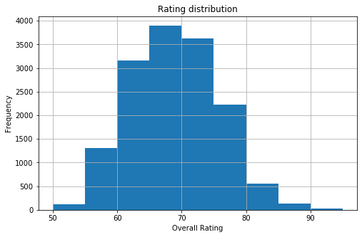

The rating distribution makes sense with one peak from 65 to 70 and most of the players are between 60 and 75 rating.

Next up, the first predictor variable of interest: **finishing**.

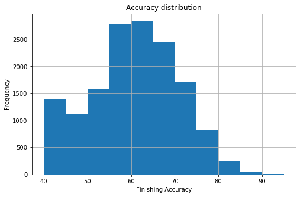

The chart has one peak on 60 and most of the players have accuracy between 55 and 70.

The minimum finishing accuracy is 40, and very low number of players are above 90.

lets see another variable:**age** for example

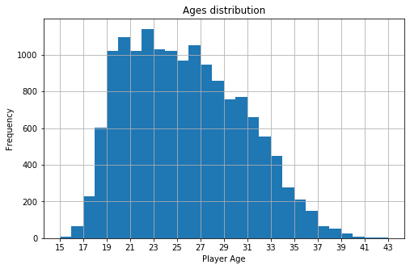

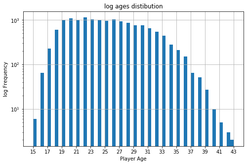

The maximun age found is 43 years old, less than 10 players are 15 years old, and the most repeated age is 22 years old.

lets move to the categorical variables: **what are the most countries have players in the dataset?**

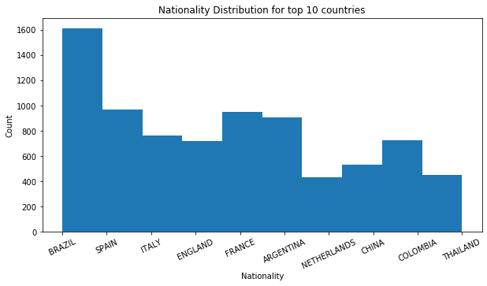

Brazil have the highest number of players in the dataset with 1600 players,then Spain,France and Argentina with around 1000 players for each of them.

**what about leagues?**

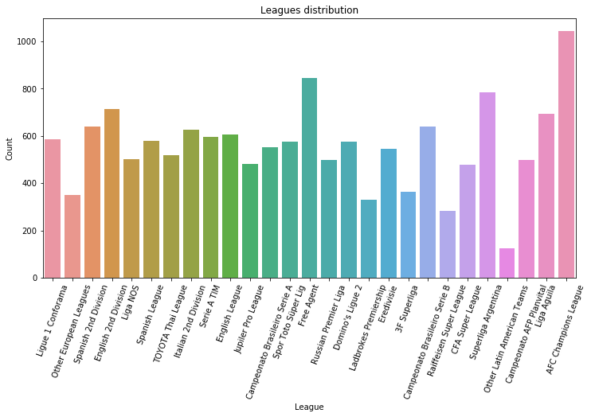

## Bivariate Exploration

To start off with, I want to look at the pairwise correlations present between features in the data.

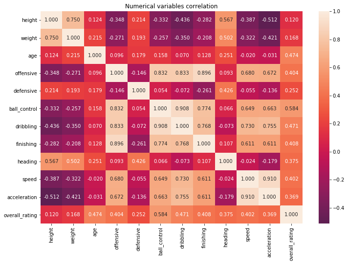

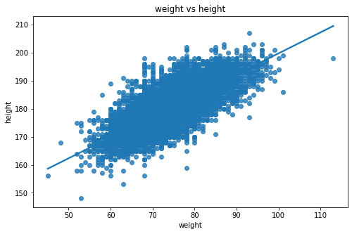

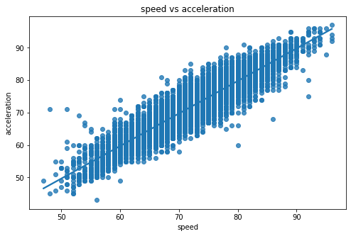

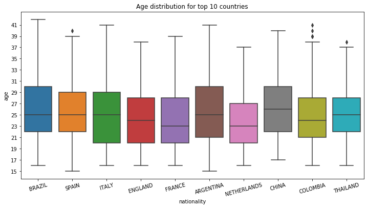

- France and Netharlands have the least median of age.
- Brazil and Argentina have the highest range of ages.
- 75% of all players are less than 30 years old.
- 50% of all players between 20 and 30 years old.

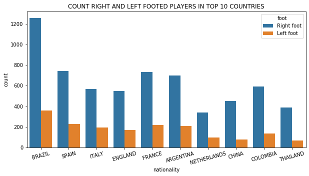

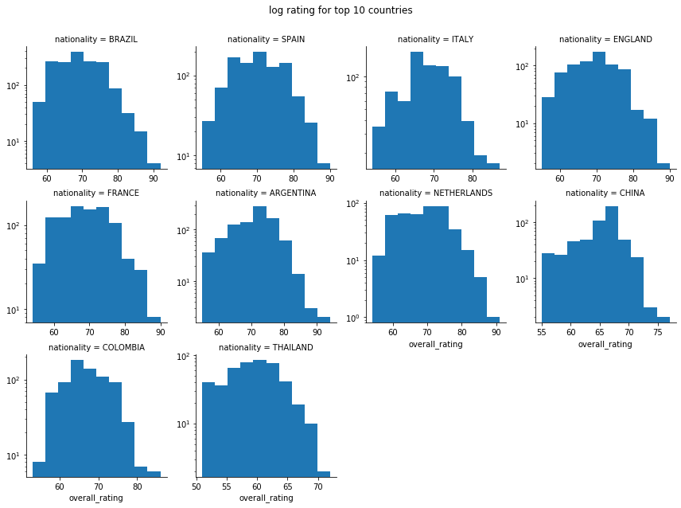

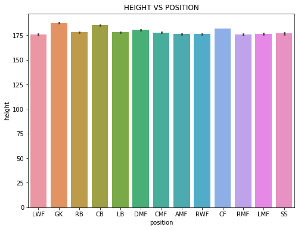

### Talk about some of the relationships you observed in this part of the investigation.

The overall rating is partly correlated with each numerical variable except height and weight.

As expected:

[output not shown]

## Multivariate Exploration

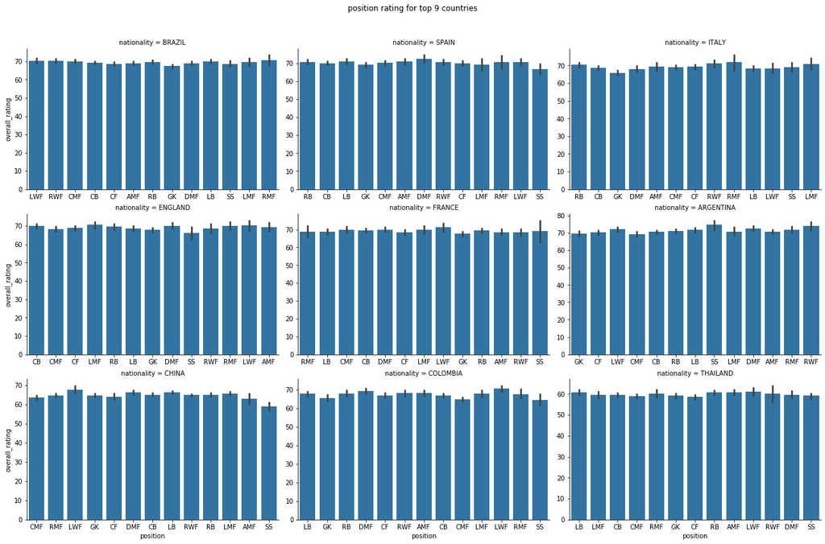

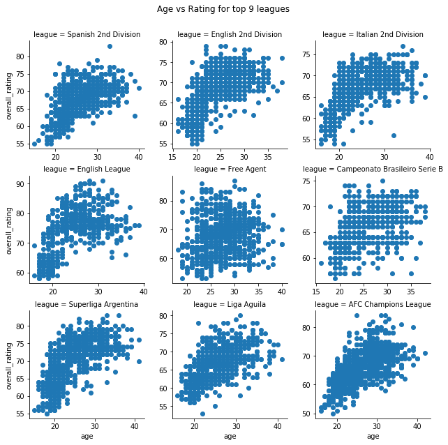